# M.Sc. Geoinformatics and Spatial Data Science - Course Program

Christian Knoth

May 26, 2021

## About this document

This document is intended to give you an introduction to the course structure of your studies and to help you plan your individual course program. At the beginning of the semester you will have to choose your courses and we offer an introduction meeting as well as personal advisory to help you do so. However, many of you usually arrive only very shortly before the start of lectures and often there is only very little time left for you to get to grips with the course structure and the choices you have. Thus, it is a good idea to start your planning before you arrive in Münster. This short introduction will help you do this so that when you arrive you already have an idea of which courses you will choose and know which open questions you need to ask.

The document consists of:

- An overview of the program´s module structure
- Brief descriptions of the modules of semesters 1 and 2 and the choice of courses
- A brief description of the course booking system
- A how-to for planning your personal course program

**Please note:** The information provided in this document is not legally binding, but only a guidance for students. The only institution that provides legally binding information is the examination office!

## Module structure

The total workload of the study program is 120 credit points (ECTS) distributed over 8 modules and 4 semesters. The third semester is reserved for doing an external semester (e.g., study abroad or conduct an internship) and in the fourth semester you will complete and defend your Master thesis. This means that the actual course program (lectures, seminars, study projects etc.) is completed in the first two semesters. Each semester is intended to contain ~30 ECTS, in total you will receive:

- 60 ECTS for courses (1st and 2nd semester)
- 30 ECTS for your external semester (3rd semester)
- 30 ECTS for writing and defending your Master thesis (4th semester)

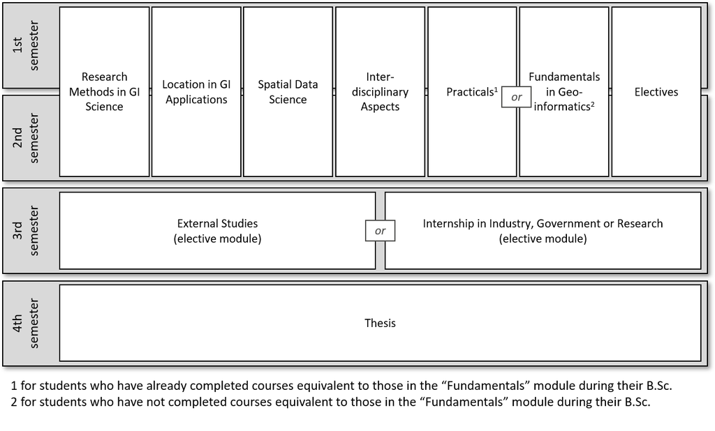

This document is concerned with how to choose courses in order to collect the 60 ECTS in the first two semesters.

**Note:** Your course program in semester 1 and 2 consists of elective and **mandatory** courses. Most of these mandatory courses are only offered **once a year**. If you miss such a course, the next chance will be one year later, when you are supposed to do your external semester. This means that you have to choose mandatory courses in the semester when they are first offered to you, otherwise you risk a delay in your studies.

### 1 Research Methods in GI Science

Module 1 consists of 3 courses with a total of 10 ECTS, all of which are *mandatory*. The figure below shows an overview of the courses of this module.

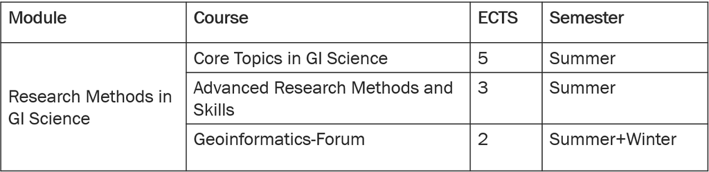

**Specifics**:

The “GI-Forum” is a colloquium where ifgi invites scientists from other Universities or research institutions to give talks about their research. To receive the 2 ECTS for this course you have to attend these talks throughout the 1st *and* 2nd semester.

### 2 Location in GI Applications

Module 2 consists of 2 courses with a total of 10 ECTS and involves some choices for students (see Specifics). The figure below shows an overview of the courses of this module.

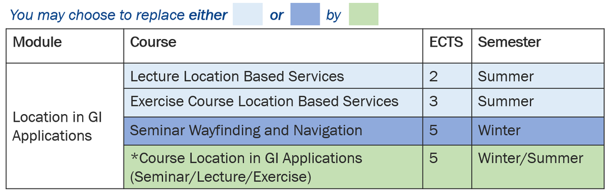

**Specifics**:

1. The courses “Location Based Services” and “Wayfinding and Navigation” are the default courses to attend within this module. However, you can choose to replace one of these two courses (*either* “Location Based Services” *or* “Wayfinding and Navigation” ) by an eligible (thematically fitting) elective course from our course program (called “Course Location in GI Applications” in the figure above). The offering of elective courses varies from semester to semester, and courses that are eligible as an elective for this module will be shown in the corresponding course overview of the module in the course booking system (see below).
2. The course “Location Based Services” is a combined lecture and exercise. You have to attend both in the same semester. This is why it is treated as one 5 ECTS course.

### 3 Spatial Data Science

Module 3 consists of 2 courses with a total of 10 ECTS and involves some choices for students (see Specifics). The figure below shows an overview of the courses of this module. Its structure is identical to the one of module 2. The figure below shows an overview of the courses of this module.

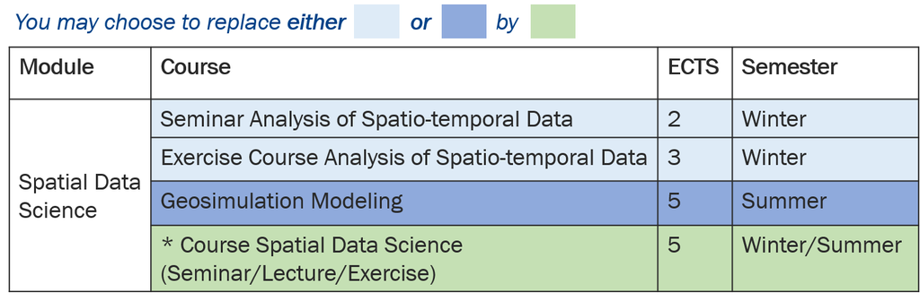

**Specifics**:

1. The courses “Analysis of Spatio-temporal Data” and “Geosimulation Modelling” are the default courses to attend within this module. However, you can choose to replace one of these two courses (*either* “Analysis of Spatio-temporal Data” *or* “Geosimulation Modelling” ) by an eligible (thematically fitting) elective course from our course program (called “Course Spatial Data Science” in the figure above). The offering of elective courses varies from semester to semester, and courses that are eligible as an elective for this module will be shown in the corresponding course overview of the module in the course booking system (see below).
2. The course “Analysis of Spatio-temporal Data” is a combined seminar and exercise. You have to attend both in the same semester. This is why it is treated as one 5 ECTS course.

### 4 Interdisciplinary Aspects

Module 4 consists of 1 course with a total of 5 ECTS that can be chosen out of three courses (see Specifics). The figure below shows an overview of the courses of this module.

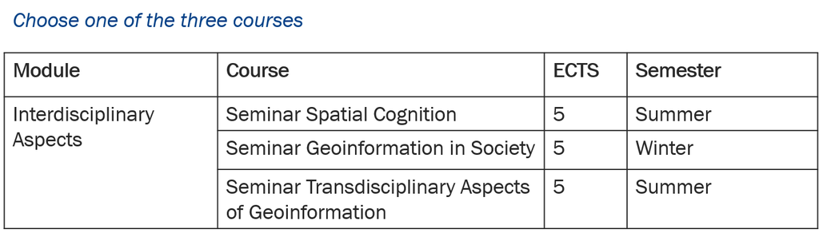

**Specifics**:

There are three courses eligible for this module: “Spatial Cognition”, “Geoinformation in Society” and “Transdiciplinary Aspects of Geoinformation”. You chose one of these 3 courses to complete this module.

### 5 Fundamentals in Geoinformatics

Module 5 consists of 3 courses with a total of 15 ECTS. The figure below shows an overview of the courses of this module.

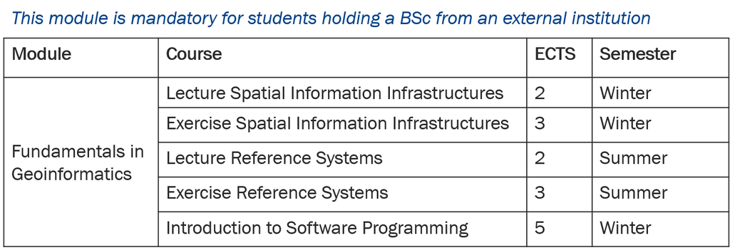

**Specifics**:

1. This module is mandatory for students who have *not* already attended equivalent courses. This is typically the case for students who did their Bachelor´s degree at an institution other than ifgi. If you did your Bachelor´s degree at an institution other than ifgi but you already attended courses equivalent to one or more of the courses in this module, you may replace those courses with elective courses from our course program. Please contact the study advisors to discuss with them whether or not this is possible.
2. The courses “Spatial Information Infrastructures” and “Reference Systems” are each a combined lecture and exercise. You have to attend the lecture and exercise in the same semester (winter semester for “Spatial Information Infrastructures” and summer semester for “Reference Systems”, respectively). This is why each of them is treated as one 5 ECTS course.

### 6 Electives

Module 6 consists of 2 courses with a total of 10 ECTS, both of which are elective courses. The figure below shows an overview of the courses of this module.

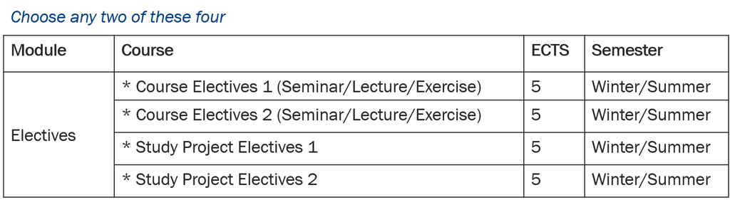

**Specifics**:

1. You can choose any combination of study projects and other courses from the course program to complete this module (one study project and one non-project course, two study projects, or two non-project courses). The offering of elective courses varies from semester to semester, and courses that are eligible as an elective for this module will be shown in the corresponding course overview of the module in the course booking system (see below).
2. If you are not studying module 7, you have to choose **at least one study project** in this module.

### 7 Practicals

Module 7 consists of 2 courses (study projects, also called project courses) with a total of 15 ECTS. Both study projects are mandatory, but the topics can be chosen from the course program. The figure below shows an overview of the courses of this module.

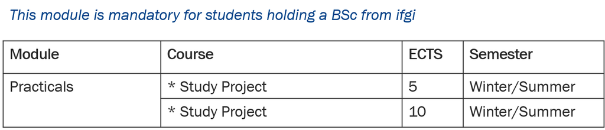

**Specifics**:

1. This module is mandatory for students who have already attended courses equivalent to those in module 5 (see above). This is the case for students who did their Bachelor´s degree at ifgi.
2. Study projects are offered every semester. The specific topics of the projects usually change every semester, as they are closely aligned with the current research in our labs. Thus, each topic is usually offered only once.

## Course booking system

To receive the ECTS at the end of each semester for the courses you have attended you need to enroll in those courses in the University´s course booking system (QISPOS). You can find it [here](https://studium.uni-muenster.de/qisserver). There is a specific period for enrolling in courses during the semester.

[figure not shown]

To find courses relevant to your study program:

- Click on *Course Overview*
- Choose *Geowissenschaften*
- Click on *3.3.3 Studiengang Geoinformatics and Spatial Data Science Master of Science (PO 2021)*

Here you will find an overview of the modules of your study program.

[figure not shown]

Click on one of the modules to see all courses that are eligible for this module and that are offered in the current semester. The example below is from summer 2021 and shows the module “Spatial Data Science”.

[figure not shown]

As you can see, the course *Geosimulation Modelling* (which is one of the default courses in this module) is offered in this semester along with two other thematically fitting courses: *Spatial Data Science with R* and *Introduction to Synthetic Aperture Radar (SAR) technology and spaceborne SAR data analysis*. The latter two are no default courses for that module, but as you have read in the module specifics above, you could in this example choose to replace either “Geosimulation Modelling” or “Analysis of Spatio-temporal Data” (offered in winter semester) by one of these two courses.

The next example shows the module “Electives” from summer semester 2021

[figure not shown]

As you can see, there are four seminars, one combined lecture/exercise and two study projects (“project course”) offered for this module. Please note that elective courses are often eligible for more than one module. In the course booking system they will appear in different modules as well, but of course each course can only be attended once. You need to decide in which module you want to choose such an elective course (this will depend on what other courses you are planning to attend and in which modules you still need to collect ECTS).

## Plan your personal course program

The next step for you will be to make up your mind about the courses you are going to attend in your first semester. We recommend these steps:

1. Go to https://master-geoinformatics.com/ and scroll down to the interactive study plan
2. Select whether you are starting in the winter or summer semester and whether you did your Bachelor´s degree at ifgi or at another institution.
3. Check the resulting study plan. It will show our recommendation for how to book mandatory and elective courses.
4. Note down all blue courses. These are mandatory and should be chosen as recommended.
5. Now check the green courses. These are courses involving choices, i.e. elective courses (modules 4 and 6) or courses that may be replaced (modules 2 and 3). Check the corresponding modules in the course booking system to see what (other) choices are available in the current semester.
6. Select courses according to the green blocks in the study plan to complete your program. You should end up with ~30 ECTS for semester 1.

**Please note** that the choices you make in semester 1 may affect the options you have in semester 2. For example: if you start in winter semester and choose to replace the course “Wayfinding and Navigation” by an eligible elective course, you can no longer replace the course “Location-Based Services” that will be offered in the second semester (summer). “Location-Based Services” will turn into a mandatory course in this case.

### Flexibility in the order of elective courses

The distribution of elective courses over the two semesters -as shown in the interactive study plan- is our recommendation. You can choose a different order. However, you need to make sure to complete ~30ECTS per semester.